# Analyzing COVID-19 Misperceptions and Psychosocial Correlates. By: Robbie Beydoun

## Loading the datasets.

```r
library(tidyverse)
load("j677_tabular_data_vis.RData")
```

## Creating new variables needed for following analyses.

```r
dt <- dt %>%
  mutate(info_seek_doc = case_when(
    Info_seeking_3 == "1" ~ "No",
    Info_seeking_3 == "2" ~ "No",
    Info_seeking_3 == "3" ~ "Yes",
    Info_seeking_3 == "4" ~ "Yes"
  ),
  info_seek_interpersonal = case_when(
    Info_seeking_4 == "1" ~ "No",
    Info_seeking_4 == "2" ~ "No",
    Info_seeking_4 == "3" ~ "Yes",
    Info_seeking_4 == "4" ~ "Yes"
  ),
  info_seek_media = case_when(
    Info_seeking_1 == "1" ~ "No",
    Info_seeking_2 == "2" ~ "No",
    Info_seeking_3 == "3" ~ "Yes",
    Info_seeking_4 == "4" ~ "Yes"
  ),
  gender = case_when(
    Gender == "2" ~ "Woman",
    Gender == "1" ~ "Man",
    Gender == "3" ~ "Woman",
  ),
  rural_urban = case_when(
    ruca_rural == "rural" ~ "Rural",
    ruca_rural == "not_rural" ~ "Urban"
  ),
  edu = case_when(
    Education == "1" ~ "less than college",
    Education == "2" ~ "less than college",
    Education == "3" ~ "less than college",
    Education == "4" ~ "college",
    Education == "5" ~ "college",
    Education == "6" ~ "graduate",
    Education == "7" ~ "graduate",
    Education == "8" ~ "graduate",
  ))
```

## Created a new summary dataset that groups the original dataset.

A.) “count”: is the number of participants following into four categories formed by crossing “rural_urban” (Rural vs. Urban) with “info_seek_doc” (Yes vs. No).

C.) “percent”: rounds the results of “frequency” to the nearest percentage point. “percent” records an integer.

```r
dt_rural_info <- dt %>%
  group_by(rural_urban, info_seek_doc) %>%
  summarize(N = n(), .groups = "drop") %>%
  mutate(freq = N/sum(N),
         pct = round((freq*100), 0))

dt_rural_info %>%
  group_by(rural_urban) %>%
  summarize(total=sum(pct))
```

| rural_urban | total |
| --- | --- |
| Rural | 33 |
| Urban | 67 |

## Bar graph from the new summary dataset.

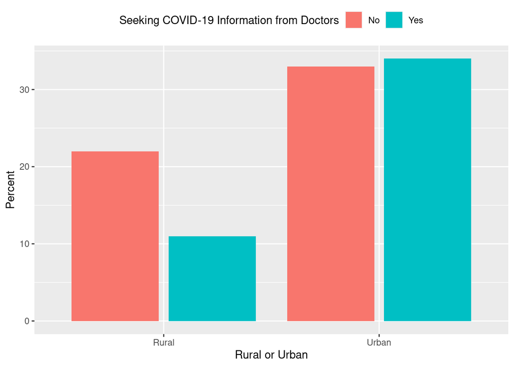

```r
p_q1b <- ggplot(dt_rural_info,
            aes(x = rural_urban, y = pct, fill = info_seek_doc))

p_q1b + geom_col(position = "dodge2") +
labs(x = "Rural or Urban", y = "Percent", fill = "Seeking COVID-19 Information from Doctors") +
theme(legend.position = "top")
```

In urban areas, the likelihood of seeking out COVID-19 related information is 50%, while the other 50% are not likely to seek out information. In rural areas, people are less likely to seek COVID-19 related information than in urban areas.

## Summary dataset that groups the original dataset that now incorporates gender.

```r
dt_rural_gender_info <- dt %>%
  group_by(rural_urban, gender, info_seek_doc) %>%
  summarize(N = n(), .groups = "drop") %>%
  mutate(freq = N/sum(N),
         pct = round((freq*100), 0))
dt_rural_gender_info
```

| rural_urban | gender | info_seek_doc | N | freq | pct |
| --- | --- | --- | --- | --- | --- |
| Rural | Man | No | 40 | 0.080 | 8 |
| Rural | Man | Yes | 31 | 0.062 | 6 |
| Rural | Woman | No | 71 | 0.142 | 14 |
| Rural | Woman | Yes | 25 | 0.050 | 5 |
| Urban | Man | No | 79 | 0.158 | 16 |
| Urban | Man | Yes | 88 | 0.176 | 18 |
| Urban | Woman | No | 86 | 0.172 | 17 |
| Urban | Woman | Yes | 80 | 0.160 | 16 |

## Bar graph from the new summary dataset that incorporates gender.

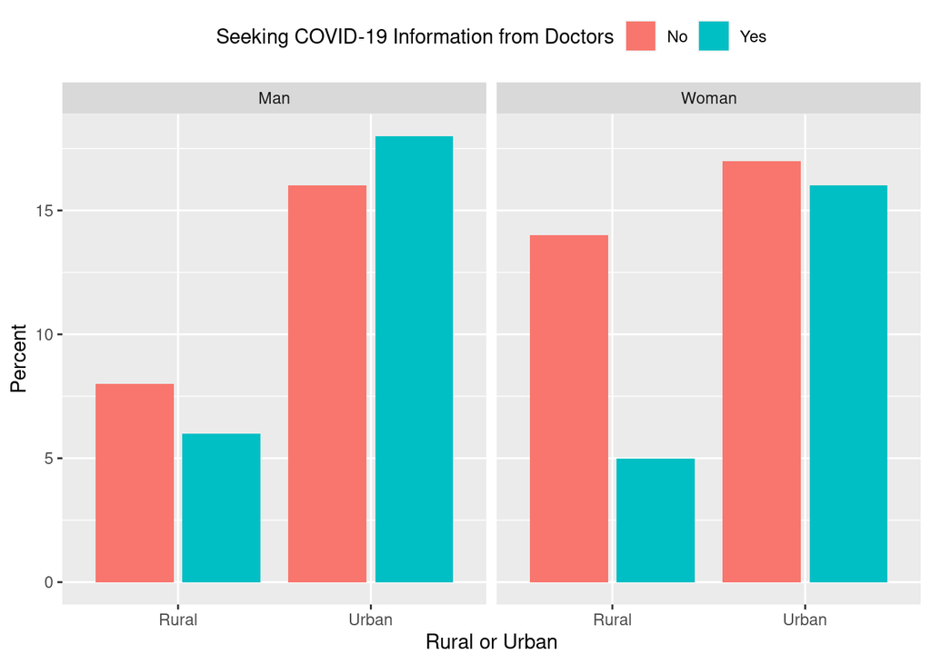

```r
p_q1d <- ggplot(dt_rural_gender_info,
            aes(x = rural_urban, y = pct, fill = info_seek_doc))


p_q1d + geom_col(position = "dodge2") +
labs(x = "Rural or Urban", y = "Percent", fill = "Seeking COVID-19 Information from Doctors") +
  theme(legend.position = "top") +
  facet_grid(~ gender)
```

## Dataset describing people’s beliefs about COVID-19.

“mis_covid_overall” is made up of the beliefs below:

Mis_covid_health_2_1: Wearing face masks can cause carbon dioxide toxicity and hence can weaken immune system. Mis_covid_health_2_2: Many countries have reached the standard for herd immunity. Mis_covid_health_2_3: Thermal scanners can detect COVID-19. Mis_covid_health_2_4: Ultra-violet (UV) lamps can be used to disinfect and are safe for humans and pets. Mis_covid_health_2_5: Hydroxychloroquine is effective in curing COVID-19. Mis_covid_health_2_6: A coronavirus vaccine used on dogs or bovine can be used to prevent COVID-19 on people. Mis_covid_health_2_7: Chlorine dioxide kits sold online under various “MMS” names — Miracle Mineral Solution, Miracle Mineral Supplement, Master Mineral Solution — will cure the coronavirus. Mis_covid_health_2_8: Only N95 masks can prevent the spread of COVID. Mis_covid_health_2_9: Sunlight actually can kill the novel coronavirus. Mis_covid_health_2_10: Drinking alcohol beverages can help prevent COVID-19.

Participants were asked to report their level of agreement on a 5-point scale (1 = strongly disagree, 5 = strongly agree).

“social_media_skepticism” = (“Sm_skepticism_27” + “Sm_skepticism_28”)/2 Sm_skepticism_27: Too often, credible news information is mixed up with misinformation on social media. Sm_skepticism_28: You can’t trust the news stories people share on social media.

“conspiracy” = (“gen_consprcy_belief_1” + “gen_consprcy_belief_2” +…+ “gen_consprcy_belief_5”)/5 gen_consprcy_belief_1: I think that many very important things happen in the world, which the public is never informed about. gen_consprcy_belief_2: I think that politicians usually do not tell us the true motives for their decisions. gen_consprcy_belief_3: I think that government agencies closely monitor all citizens. gen_consprcy_belief_4: I think that events which superficially seem to lack a connection are often the result of secret activities. gen_consprcy_belief_5: I think that there are secret organizations that greatly influence political decisions.

Participants were asked to report how likely they think each statement is true on a 7-point scale (1 = certainly not, 7 = certain).

“nationalism” = (“Nationalism_1” + “Nationalism_2” + …+ “Nationalism_4”)/4 Nationalism_1: I would rather be a citizen of my country than of any other country. Nationalism_2: The world would be a better place if people from other countries were more like my country. Nationalism_3: My country is a better country than most other countries. Nationalism_4: It makes me proud when my country does well in international sports.

Participants were asked to report their level of agreement on a 5-point scale (1 = strongly disagree, 5 = strongly agree).

“trust_scientists” = “Institutional_trust_5” (converted to numeric) Institutional_trust_5: The Scientific Community

Participants were asked to rate how much trust they have in the institution on a 0-100 scale.

“trust_press” = “Institutional_trust_6” (converted to numeric) Institutional_trust_6: The Press

Participants were asked to rate how much trust they have in the institution on a 0-100 scale.

“trust_medical” = “Institutional_trust_11” (converted to numeric) Institutional_trust_11: The Medical Community

Participants were asked to rate how much trust they have in the institution on a 0-100 scale.

“religiosity” = “religiosity_2” (converted to numeric) religiosity_2: How often do you go to religious services?

Participants responded on a 5-point scale, ranging from 1 = never to 5 = every week.

“age” = “age” (converted to numeric)

```r
dt_ols_corr <- dt %>%
  mutate(Mis_covid_health_2_1 = as.numeric(Mis_covid_health_2_1),
         Mis_covid_health_2_2 = as.numeric(Mis_covid_health_2_2),
         Mis_covid_health_2_3 = as.numeric(Mis_covid_health_2_3),
         Mis_covid_health_2_4 = as.numeric(Mis_covid_health_2_4),
         Mis_covid_health_2_5 = as.numeric(Mis_covid_health_2_5),
         Mis_covid_health_2_6 = as.numeric(Mis_covid_health_2_6),
         Mis_covid_health_2_7 = as.numeric(Mis_covid_health_2_7),
         Mis_covid_health_2_8 = as.numeric(Mis_covid_health_2_8),
         Mis_covid_health_2_9 = as.numeric(Mis_covid_health_2_9),
         Mis_covid_health_2_10 = as.numeric(Mis_covid_health_2_10),
         Sm_skepticism_27 = as.numeric(Sm_skepticism_27),
         Sm_skepticism_28 = as.numeric(Sm_skepticism_28),
         gen_consprcy_belief_1 = as.numeric(gen_consprcy_belief_1),
         gen_consprcy_belief_2 = as.numeric(gen_consprcy_belief_2),
         gen_consprcy_belief_3 = as.numeric(gen_consprcy_belief_3),
         gen_consprcy_belief_4 = as.numeric(gen_consprcy_belief_4),
         gen_consprcy_belief_5 = as.numeric(gen_consprcy_belief_5),
         Nationalism_1 = as.numeric(Nationalism_1),
         Nationalism_2 = as.numeric(Nationalism_2),
         Nationalism_3 = as.numeric(Nationalism_3),
         Nationalism_4 = as.numeric(Nationalism_4),
         Institutional_trust_5 = as.numeric(Institutional_trust_5),
         Institutional_trust_6 = as.numeric(Institutional_trust_6),
         Institutional_trust_11 = as.numeric(Institutional_trust_11),
         religiosity_2 = as.numeric(religiosity_2),
         age = as.numeric(age),
         mis_covid_overall = (Mis_covid_health_2_1 + Mis_covid_health_2_2 +
                                Mis_covid_health_2_3 + Mis_covid_health_2_4 +
                                Mis_covid_health_2_5 + Mis_covid_health_2_6 +
                                Mis_covid_health_2_7 + Mis_covid_health_2_8 +
                                Mis_covid_health_2_9 + Mis_covid_health_2_10)/10,
         social_media_skepticism = (Sm_skepticism_27 + Sm_skepticism_28)/2,
         conspiracy = (gen_consprcy_belief_1 + gen_consprcy_belief_2 +
                         gen_consprcy_belief_3 + gen_consprcy_belief_4 +
                         gen_consprcy_belief_5)/5,
         nationalism = (Nationalism_1 + Nationalism_2 +
                          Nationalism_3 + Nationalism_4)/4,
         trust_scientists = Institutional_trust_5,
         trust_press = Institutional_trust_6,
         trust_medical = Institutional_trust_11,
         religiosity = religiosity_2, age = age) %>%
  select(mis_covid_overall, social_media_skepticism, conspiracy,
         nationalism, trust_scientists, trust_press, trust_medical,
         religiosity, age)

dt_ols_corr
```

| mis_covid_overall | social_media_skepticism | conspiracy | nationalism | trust_scientists | trust_press | trust_medical | religiosity | age |
| --- | --- | --- | --- | --- | --- | --- | --- | --- |
| 3.5 | 1.0 | 5.2 | 3.75 | 3 | 1 | 2 | 3 | 55 |
| 2.5 | 5.5 | 6.4 | 2.75 | 55 | 40 | 55 | 1 | 67 |
| 3.9 | 4.5 | 4.4 | 3.00 | 47 | 29 | 37 | 1 | 57 |
| 1.0 | 5.5 | 4.6 | 1.50 | 70 | 5 | 60 | 1 | 55 |
| 3.2 | 7.0 | 6.2 | 2.50 | 50 | 50 | 50 | 1 | 26 |
| 2.7 | 4.5 | 4.6 | 4.50 | 89 | 72 | 81 | 1 | 59 |
| 1.0 | 5.5 | 2.2 | 4.25 | 92 | 75 | 98 | 4 | 56 |
| 2.0 | 3.5 | 4.8 | 3.75 | 88 | 70 | 89 | 1 | 37 |
| 2.7 | 5.5 | 1.4 | 5.00 | 99 | 52 | 92 | 3 | 66 |
| 2.8 | 6.0 | 4.0 | 3.75 | 77 | 41 | 77 | 5 | 71 |

[output cut: 490 more lines]

## Correlation matrix.

```r
library(psych)
glimpse(dt_ols_corr)
```

```
## Rows: 500
## Columns: 9
## $ mis_covid_overall       <dbl> 3.5, 2.5, 3.9, 1.0, 3.2, 2.7, 1.0, 2.0, 2.7, 2…
## $ social_media_skepticism <dbl> 1.0, 5.5, 4.5, 5.5, 7.0, 4.5, 5.5, 3.5, 5.5, 6…
## $ conspiracy              <dbl> 5.2, 6.4, 4.4, 4.6, 6.2, 4.6, 2.2, 4.8, 1.4, 4…
## $ nationalism             <dbl> 3.75, 2.75, 3.00, 1.50, 2.50, 4.50, 4.25, 3.75…
## $ trust_scientists        <dbl> 3, 55, 47, 70, 50, 89, 92, 88, 99, 77, 72, 52,…
## $ trust_press             <dbl> 1, 40, 29, 5, 50, 72, 75, 70, 52, 41, 74, 62, …
## $ trust_medical           <dbl> 2, 55, 37, 60, 50, 81, 98, 89, 92, 77, 50, 64,…
## $ religiosity             <dbl> 3, 1, 1, 1, 1, 1, 4, 1, 3, 5, 1, 3, 3, 2, 5, 1…
## $ age                     <dbl> 55, 67, 57, 55, 26, 59, 56, 37, 66, 71, 67, 27…
```

```r
lowerCor(dt_ols_corr)
```

```
##                         ms_c_ scl__ cnspr ntnls trst_s trst_p trst_m rlgst
## mis_covid_overall        1.00
## social_media_skepticism  0.00  1.00
## conspiracy               0.32  0.30  1.00
## nationalism              0.13  0.15  0.18  1.00
## trust_scientists        -0.17  0.01 -0.29  0.13  1.00
## trust_press             -0.09 -0.15 -0.30  0.01  0.68   1.00
## trust_medical           -0.15  0.07 -0.22  0.22  0.76   0.53   1.00
## religiosity              0.23  0.07  0.09  0.20  0.00  -0.03   0.01   1.00
## age                     -0.31  0.20 -0.04  0.23  0.06  -0.13   0.11  -0.02
##                         age
## mis_covid_overall
## social_media_skepticism
## conspiracy
## nationalism
## trust_scientists
## trust_press
## trust_medical
## religiosity
## age                      1.00
```

The variable of conspiracy has the strongest positive correlation with “mis_covid_overall”.

The variable of age has the strongest negative correlation with “mis_covid_overall”.

## Colored correlation plot.

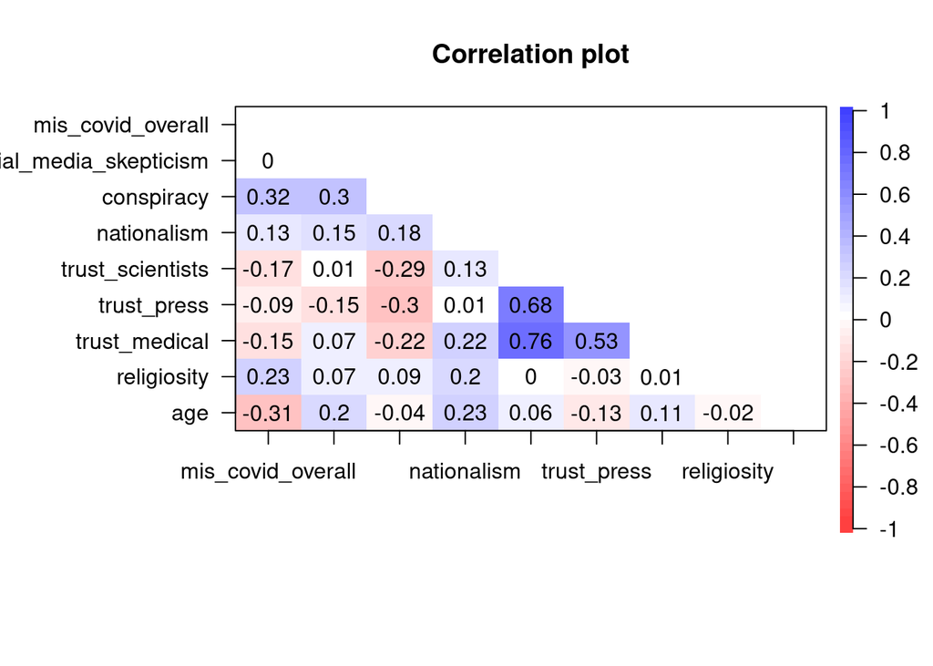

```r
corPlot(dt_ols_corr, numbers = T, upper=FALSE, diag=FALSE, scale = F)
```

## New dataset called “dt_ols”

Made up of the variables in “dt_ols_corr”, plus “rural_urban”, “gender”, and “edu” from dt.

```r
dt_ols <- dt %>%
  mutate(mis_covid_overall = dt_ols_corr$mis_covid_overall,
         social_media_skepticism = dt_ols_corr$social_media_skepticism,
         conspiracy = dt_ols_corr$conspiracy,
         nationalism = dt_ols_corr$nationalism,
         trust_scientists = dt_ols_corr$trust_scientists,
         trust_press = dt_ols_corr$trust_press,
         trust_medical = dt_ols_corr$trust_medical,
         religiosity = dt_ols_corr$religiosity,
         age = dt_ols_corr$age) %>%
  select(mis_covid_overall,social_media_skepticism,conspiracy,
         nationalism,trust_scientists,trust_press,trust_medical,
         religiosity,age,rural_urban,gender,edu)

dt_ols
```

| mis_covid_overall | social_media_skepticism | conspiracy | nationalism | trust_scientists | trust_press | trust_medical | religiosity | age | rural_urban | gender | edu |
| --- | --- | --- | --- | --- | --- | --- | --- | --- | --- | --- | --- |
| 3.5 | 1.0 | 5.2 | 3.75 | 3 | 1 | 2 | 3 | 55 | Urban | Woman | college |
| 2.5 | 5.5 | 6.4 | 2.75 | 55 | 40 | 55 | 1 | 67 | Urban | Man | less than college |
| 3.9 | 4.5 | 4.4 | 3.00 | 47 | 29 | 37 | 1 | 57 | Urban | Woman | less than college |
| 1.0 | 5.5 | 4.6 | 1.50 | 70 | 5 | 60 | 1 | 55 | Urban | Woman | graduate |
| 3.2 | 7.0 | 6.2 | 2.50 | 50 | 50 | 50 | 1 | 26 | Rural | Man | less than college |
| 2.7 | 4.5 | 4.6 | 4.50 | 89 | 72 | 81 | 1 | 59 | Urban | Woman | college |
| 1.0 | 5.5 | 2.2 | 4.25 | 92 | 75 | 98 | 4 | 56 | Rural | Man | graduate |
| 2.0 | 3.5 | 4.8 | 3.75 | 88 | 70 | 89 | 1 | 37 | Urban | Man | graduate |
| 2.7 | 5.5 | 1.4 | 5.00 | 99 | 52 | 92 | 3 | 66 | Urban | Man | college |
| 2.8 | 6.0 | 4.0 | 3.75 | 77 | 41 | 77 | 5 | 71 | Urban | Man | college |

[output cut: 490 more lines]

## Multiple regression model

Using “mis_covid_overall” as the outcome variable (DV), and the following as the independent variables:

social_media_skepticism conspiracy nationalism trust_scientists trust_press trust_medical religiosity rural_urban age gender edu

```r
ols <- lm(formula = mis_covid_overall ~ social_media_skepticism + conspiracy +
          nationalism + trust_scientists + trust_press + trust_medical + religiosity +
          rural_urban + age + gender + edu,
          data = dt_ols)

summary(ols)
```

```
##
## Call:
## lm(formula = mis_covid_overall ~ social_media_skepticism + conspiracy +
##     nationalism + trust_scientists + trust_press + trust_medical +
##     religiosity + rural_urban + age + gender + edu, data = dt_ols)
##
## Residuals:
##     Min      1Q  Median      3Q     Max
## -2.9339 -0.7020 -0.0223  0.6866  3.4517
##
## Coefficients:
##                           Estimate Std. Error t value Pr(>|t|)
## (Intercept)              2.7068813  0.3750398   7.218 2.04e-12 ***
## social_media_skepticism -0.0569578  0.0410172  -1.389  0.16558
## conspiracy               0.2509356  0.0429585   5.841 9.48e-09 ***
## nationalism              0.2071123  0.0664696   3.116  0.00194 **
## trust_scientists        -0.0028341  0.0029226  -0.970  0.33267
## trust_press              0.0001635  0.0021329   0.077  0.93893
## trust_medical           -0.0019251  0.0027769  -0.693  0.48848
## religiosity              0.1380767  0.0325956   4.236 2.72e-05 ***
## rural_urbanUrban        -0.1216800  0.1052707  -1.156  0.24830
## age                     -0.0223224  0.0031071  -7.184 2.55e-12 ***
## genderWoman             -0.2633773  0.0999800  -2.634  0.00870 **
## edugraduate              0.0065332  0.1483344   0.044  0.96489
## eduless than college    -0.1126163  0.1077706  -1.045  0.29656
## ---
## Signif. codes:  0 '***' 0.001 '**' 0.01 '*' 0.05 '.' 0.1 ' ' 1
##
## Residual standard error: 1.077 on 487 degrees of freedom
## Multiple R-squared:  0.2658, Adjusted R-squared:  0.2477
## F-statistic: 14.69 on 12 and 487 DF,  p-value: < 2.2e-16
```

```r
glimpse(dt_ols)
```

```
## Rows: 500
## Columns: 12
## $ mis_covid_overall       <dbl> 3.5, 2.5, 3.9, 1.0, 3.2, 2.7, 1.0, 2.0, 2.7, 2…
## $ social_media_skepticism <dbl> 1.0, 5.5, 4.5, 5.5, 7.0, 4.5, 5.5, 3.5, 5.5, 6…
## $ conspiracy              <dbl> 5.2, 6.4, 4.4, 4.6, 6.2, 4.6, 2.2, 4.8, 1.4, 4…
## $ nationalism             <dbl> 3.75, 2.75, 3.00, 1.50, 2.50, 4.50, 4.25, 3.75…
## $ trust_scientists        <dbl> 3, 55, 47, 70, 50, 89, 92, 88, 99, 77, 72, 52,…
## $ trust_press             <dbl> 1, 40, 29, 5, 50, 72, 75, 70, 52, 41, 74, 62, …
## $ trust_medical           <dbl> 2, 55, 37, 60, 50, 81, 98, 89, 92, 77, 50, 64,…
## $ religiosity             <dbl> 3, 1, 1, 1, 1, 1, 4, 1, 3, 5, 1, 3, 3, 2, 5, 1…
## $ age                     <dbl> 55, 67, 57, 55, 26, 59, 56, 37, 66, 71, 67, 27…
## $ rural_urban             <chr> "Urban", "Urban", "Urban", "Urban", "Rural", "…
## $ gender                  <chr> "Woman", "Man", "Woman", "Woman", "Man", "Woma…
## $ edu                     <chr> "college", "less than college", "less than col…
```

All the significant independent variables: conspiracy, nationalism, religiosity, age,and genderWoman.

```r
library(broom)

out_conf <- tidy(ols)

out_conf
```

| term | estimate | std.error | statistic | p.value |
| --- | --- | --- | --- | --- |
| (Intercept) | 2.706881315 | 0.375039817 | 7.21758382 | 2.044297e-12 |
| social_media_skepticism | -0.056957850 | 0.041017234 | -1.38863214 | 1.655794e-01 |
| conspiracy | 0.250935623 | 0.042958513 | 5.84134798 | 9.478348e-09 |
| nationalism | 0.207112310 | 0.066469637 | 3.11589352 | 1.942138e-03 |
| trust_scientists | -0.002834128 | 0.002922642 | -0.96971462 | 3.326701e-01 |
| trust_press | 0.000163505 | 0.002132934 | 0.07665732 | 9.389276e-01 |
| trust_medical | -0.001925104 | 0.002776881 | -0.69326141 | 4.884760e-01 |
| religiosity | 0.138076740 | 0.032595649 | 4.23604818 | 2.721025e-05 |
| rural_urbanUrban | -0.121679957 | 0.105270737 | -1.15587636 | 2.482985e-01 |
| age | -0.022322447 | 0.003107062 | -7.18442387 | 2.546857e-12 |

[output cut: 3 more lines]

## Figure to visually summarize the estimated regression coefficients and 95% confidence intervals.

```r
library(socviz)

out_conf <- tidy(ols, conf.int = TRUE)
out_conf
```

| term | estimate | std.error | statistic | p.value | conf.low | conf.high |
| --- | --- | --- | --- | --- | --- | --- |
| (Intercept) | 2.706881315 | 0.375039817 | 7.21758382 | 2.044297e-12 | 1.969985418 | 3.443777212 |
| social_media_skepticism | -0.056957850 | 0.041017234 | -1.38863214 | 1.655794e-01 | -0.137550444 | 0.023634744 |
| conspiracy | 0.250935623 | 0.042958513 | 5.84134798 | 9.478348e-09 | 0.166528713 | 0.335342533 |
| nationalism | 0.207112310 | 0.066469637 | 3.11589352 | 1.942138e-03 | 0.076509637 | 0.337714983 |
| trust_scientists | -0.002834128 | 0.002922642 | -0.96971462 | 3.326701e-01 | -0.008576672 | 0.002908416 |
| trust_press | 0.000163505 | 0.002132934 | 0.07665732 | 9.389276e-01 | -0.004027383 | 0.004354393 |
| trust_medical | -0.001925104 | 0.002776881 | -0.69326141 | 4.884760e-01 | -0.007381250 | 0.003531042 |
| religiosity | 0.138076740 | 0.032595649 | 4.23604818 | 2.721025e-05 | 0.074031273 | 0.202122206 |
| rural_urbanUrban | -0.121679957 | 0.105270737 | -1.15587636 | 2.482985e-01 | -0.328520860 | 0.085160946 |
| age | -0.022322447 | 0.003107062 | -7.18442387 | 2.546857e-12 | -0.028427348 | -0.016217546 |

[output cut: 3 more lines]

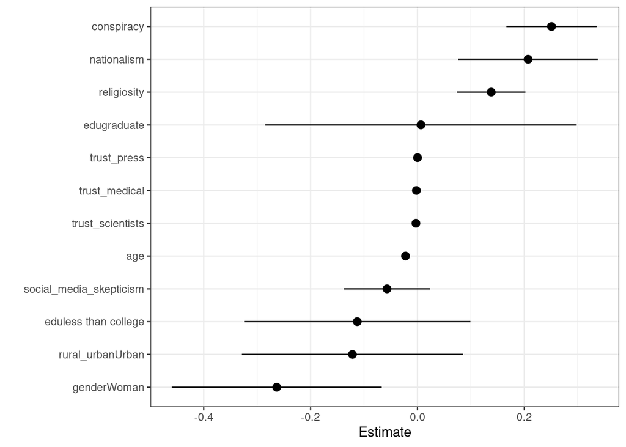

```r
out_conf <- subset(out_conf,
                   term %nin% "(Intercept)")

p <- ggplot(out_conf,
            mapping = aes(x = reorder(term, estimate),
                          y = estimate,
                          ymin = conf.low,
                          ymax = conf.high))

p + geom_pointrange() +
  coord_flip() +
  labs(x="", y="Estimate") +
  theme_bw()
```

Thanks for taking the time to check out this project, Curran! I hope you enjoyed seeing the R skills that I have garned.